# BIOL 322 Lab 4. Selection

Angela J. Roles

Spring 2026

When you have completed the exercise below, submit your model and your lab write-up via the Google Drive Form (https://forms.gle/E3QLACX1aA2Q6ist5). Responses due by the following week’s lab period.

During lab, we will work in groups. Here are the groups assigned for today’s exercise:

| Group | Partner 1 | Partner 2 |
| --- | --- | --- |
| 1 | Emily F. | Andrea |
| 2 | Amelia | Sophie |
| 3 | Hunter | Emily S. |
| 4 | Ricarda | Calvin |
| 5 | Diane | Merry |
| 6 | Kalyan | Revanth |
| 7 | Julia | Vaughn |
| 8 | Isabel | My |
| 9 | Shaina | Elise |
| 10 | Aidan | Martha (absent) |

## Overview

Last week, we built a model incorporating genetic drift. This week, we’ll incorporate selection too! To do this, we’ll start with our drift model and apply selection to the survival of zygotes to adulthood:

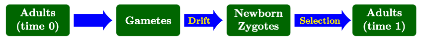

Image of the life cycle showing selection occurring during the maturation of juveniles into adults

Remember that **selection occurs when genotypes differ in their fitness**. We will add relative fitness terms for each genotype to determine how many new zygotes are created each generation.

For reference, here’s an image of the completed model:

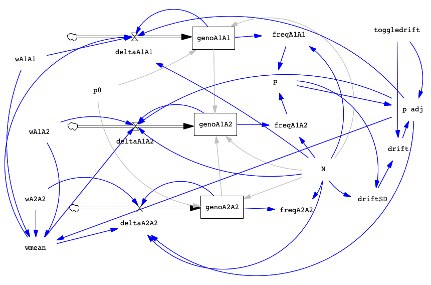

Image of the completed model with selection and drift

## Add Selection to the Drift Model

Open your drift model from last week and save it as `selection.mdl`.

### Genotype fitness and mean population fitness

Create the following four variables and place arrows as indicated:

| Variable Name | Description | Arrow pointing to | Arrow arriving from |
| --- | --- | --- | --- |
| **wA1A1** | fitness of genotype A1A1 | deltaA1A1; wmean | none |
| **wA1A2** | fitness of genotype A1A2 | deltaA1A2; wmean | none |
| **wA2A2** | fitness of genotype A2A2 | deltaA2A2; wmean | none |
| **wmean** | population mean fitness | deltaA1A1; deltaA1A2; deltaA2A2 | wA1A1; wA1A2; wA2A2; p adj |

Adjust each fitness variable as follows:

| Variable Name | Equation | Min | Max | Incr |
| --- | --- | --- | --- | --- |
| **wA1A1** | 1 | 0 | 1 | 0.01 |
| **wA1A2** | 1 | 0 | 1 | 0.01 |
| **wA2A2** | 1 | 0 | 1 | 0.01 |

Set the equation for **wmean** to: `wmean = (wA1A1*p adj*p adj) + (wA1A2*2*p adj*(1-p adj) ) + (wA2A2*(1-p adj)*(1-p adj) )`

### Adjusting flows

Update the flows to include selection:

- `deltaA1A1 = (N * p adj * p adj * wA1A1 / wmean) - genoA1A1`
- `deltaA1A2 = (N * 2 * p adj * (1 - p adj) * wA1A2 / wmean) - genoA1A2`
- `deltaA2A2 = (N * (1 - p adj) * (1 - p adj) * wA2A2 / wmean) - genoA2A2`

## Lab Write-Up

### Selection Reference Table

| Type of Selection | Highest fitness | Inheritance pattern | wA1A1 | wA1A2 | wA2A2 |
| --- | --- | --- | --- | --- | --- |
| None | None / All | NA | 1 | 1 | 1 |
| Directional | A1A1 | A1 dominant | 1 | 1 | 0.6 |
| Het. advantage | A1A2 | overdominance | 0.7 | 1 | 0.8 |
| Directional | A1A1 | A1 recessive | 1 | 0.95 | 0.95 |
| Directional | A1A1 | codominance | 1 | 0.9 | 0.8 |
| Het. disadvantage | A1A1 or A2A2 | underdominance | 0.9 | 0.7 | 1 |

### Questions

1. **Explore selection and inheritance (No drift).** Run these scenarios and summarize your observations:

| Trial | Type | p0 | wA1A1 | wA1A2 | wA2A2 | N | Time | Drift |
| --- | --- | --- | --- | --- | --- | --- | --- | --- |
| 1a | Directional | 0.9 | 0.7 | 1 | 1 | 500 | 200 | 0 |
| 1b | Het. advantage | 0.1 | 0.7 | 1 | 0.6 | 500 | 200 | 0 |
| 1c | Directional | 0.9 | 0.95 | 0.95 | 1 | 500 | 200 | 0 |
| 1d | Directional | 0.9 | 0.7 | 0.85 | 1 | 500 | 200 | 0 |
| 1e | Het. disadvantage | 0.3 | 0.9 | 0.7 | 1 | 500 | 200 | 0 |

2. **Effect of initial allele frequency.** Compare outcomes for common vs. rare favored alleles.

[output not shown]

3. **Interaction of selection and drift.** Run each parameter set 1 time without drift and 10 times with drift.

| Description | Trial | *N<sub>e</sub>s* | wA1A1 | wA1A2 | wA2A2 | p0 | N | Time | Drift |
| --- | --- | --- | --- | --- | --- | --- | --- | --- | --- |
| **Rare, s=0.1** | 3a | 100 | 1 | 0.95 | 0.9 | 0.01 | 1000 | 200 | 1-10 |
|  | 3b | 10 | 1 | 0.95 | 0.9 | 0.01 | 100 | 200 | 1-10 |
|  | 3c | 1 | 1 | 0.95 | 0.9 | 0.01 | 10 | 200 | 1-10 |
| **Common, s=0.1** | 3d | 100 | 1 | 0.95 | 0.9 | 0.5 | 1000 | 200 | 1-10 |
|  | 3e | 10 | 1 | 0.95 | 0.9 | 0.5 | 100 | 200 | 1-10 |
|  | 3f | 1 | 1 | 0.95 | 0.9 | 0.5 | 10 | 200 | 1-10 |
| **Rare, s=0.4** | 3g | 4 | 1 | 0.8 | 0.6 | 0.1 | 10 | 200 | 1-10 |
|  | 3h | 40 | 1 | 0.8 | 0.6 | 0.1 | 100 | 200 | 1-10 |

4. **Reflection.** How has this model deepened your understanding of these concepts?

**Submit your model and responses via the [Google Drive Form](https://forms.gle/E3QLACX1aA2Q6ist5).**